# The dependency network of all CRAN packages

2020-08-10

In the introduction we have see that a dependency network can be built using `get_dep_df()`. While it is theoretically possible to use `get_dep_df()` iteratively to obtain all dependencies of **all** packages available on [CRAN](https://cran.r-project.org), it is not practical to do so. This package provides two functions `get_dep_all_packages()` and `get_graph_all_packges()` for obtaining the dependencies of all CRAN packages directly, as well as an example dataset.

```r
library(crandep)
library(dplyr)
library(ggplot2)
library(igraph)
library(visNetwork)
```

## All types of dependencies, in a data frame

The example dataset `cran_dependencies` contains all dependencies as of 2020-05-09.

```r
data(cran_dependencies)
cran_dependencies
```

```
#> # A tibble: 211,381 x 4
#>    from  to             type     reverse
#>    <chr> <chr>          <chr>    <lgl>
#>  1 A3    xtable         depends  FALSE
#>  2 A3    pbapply        depends  FALSE
#>  3 A3    randomForest   suggests FALSE
#>  4 A3    e1071          suggests FALSE
#>  5 aaSEA DT             imports  FALSE
#>  6 aaSEA networkD3      imports  FALSE
#>  7 aaSEA shiny          imports  FALSE
#>  8 aaSEA shinydashboard imports  FALSE
#>  9 aaSEA magrittr       imports  FALSE
#> 10 aaSEA Bios2cor       imports  FALSE
#> # … with 211,371 more rows
```

```r
dplyr::count(cran_dependencies, type, reverse)
```

```
#> # A tibble: 8 x 3
#>   type       reverse     n
#>   <chr>      <lgl>   <int>
#> 1 depends    FALSE   11123
#> 2 depends    TRUE     9672
#> 3 imports    FALSE   57617
#> 4 imports    TRUE    51913
#> 5 linking to FALSE    3433
#> 6 linking to TRUE     3721
#> 7 suggests   FALSE   35018
#> 8 suggests   TRUE    38884
```

This is essentially a snapshot of CRAN. We can obtain all the current dependencies using `get_dep_all_packages()`, which requires no arguments:

```r
df0.cran <- get_dep_all_packages()
head(df0.cran)
```

```
#>    from             to    type reverse
#> 2 aaSEA             DT imports   FALSE
#> 3 aaSEA      networkD3 imports   FALSE
#> 4 aaSEA          shiny imports   FALSE
#> 5 aaSEA shinydashboard imports   FALSE
#> 6 aaSEA       magrittr imports   FALSE
#> 7 aaSEA       Bios2cor imports   FALSE
```

```r
dplyr::count(df0.cran, type, reverse) # numbers in general larger than above
```

```
#>         type reverse     n
#> 1    depends   FALSE 11076
#> 2    depends    TRUE  9640
#> 3    imports   FALSE 61676
#> 4    imports    TRUE 55251
#> 5 linking to   FALSE  3745
#> 6 linking to    TRUE  4035
#> 7   suggests   FALSE 38102
#> 8   suggests    TRUE 41894
```

## Network of one type of dependencies, as an igraph object

We can build dependency network using `get_graph_all_packages()`. Furthermore, we can verify that the forward and reverse dependency networks are (almost) the same, by looking at their size (number of edges) and order (number of nodes).

```r
g0.depends <- get_graph_all_packages(type = "depends")
g0.rev_depends <- get_graph_all_packages(type = "reverse depends")
g0.depends
```

```
#> IGRAPH 24801a7 DN-- 4811 8023 --
#> + attr: name (v/c), type (e/c), reverse (e/l)
#> + edges from 24801a7 (vertex names):
#>  [1] A3         ->xtable     A3         ->pbapply    abc        ->abc.data
#>  [4] abc        ->nnet       abc        ->quantreg   abc        ->MASS
#>  [7] abc        ->locfit     abcdeFBA   ->Rglpk      abcdeFBA   ->rgl
#> [10] abcdeFBA   ->corrplot   abcdeFBA   ->lattice    ABCp2      ->MASS
#> [13] abctools   ->abc        abctools   ->abind      abctools   ->plyr
#> [16] abctools   ->Hmisc      abd        ->nlme       abd        ->lattice
#> [19] abd        ->mosaic     abodOutlier->cluster    AbSim      ->ape
#> [22] AbSim      ->poweRlaw   Ac3net     ->data.table acc        ->mhsmm
#> + ... omitted several edges
```

```r
g0.rev_depends
```

```
#> IGRAPH 13318a7 DN-- 4811 8023 --
#> + attr: name (v/c), type (e/c), reverse (e/l)
#> + edges from 13318a7 (vertex names):
#>  [1] abc     ->abctools     abc     ->EasyABC      abc.data->abc
#>  [4] abd     ->tigerstats   abind   ->abctools     abind   ->BCBCSF
#>  [7] abind   ->CPMCGLM      abind   ->depth        abind   ->dgmb
#> [10] abind   ->dynamo       abind   ->FactorCopula abind   ->fractaldim
#> [13] abind   ->funLBM       abind   ->informR      abind   ->interplot
#> [16] abind   ->magic        abind   ->mlma         abind   ->mlogitBMA
#> [19] abind   ->multicon     abind   ->MultiPhen    abind   ->multipol
#> [22] abind   ->mvmesh       abind   ->mvSLOUCH     abind   ->plfm
#> + ... omitted several edges
```

The dependency words accepted by the argument `type` is the same as in `get_dep()` and `get_dep_df()`. The two networks’ size and order should be very close if not identical to each other. Because of the dependency direction, their edge lists should be the same but with the column names `from` and `to` swapped.

For verification, the exact same graphs can be obtained by filtering the data frame for the required dependency and applying `df_to_graph()`:

```r
g1.depends <- df0.cran %>%
    dplyr::filter(type == "depends" & !reverse) %>%
    df_to_graph(nodelist = dplyr::rename(df0.cran, name = from))
g1.rev_depends <- df0.cran %>%
    dplyr::filter(type == "depends" & reverse) %>%
    df_to_graph(nodelist = dplyr::rename(df0.cran, name = from))
g1.depends # same as g0.depends
```

```
#> IGRAPH 56968cf DN-- 4811 8023 --
#> + attr: name (v/c), type (e/c), reverse (e/l)
#> + edges from 56968cf (vertex names):
#>  [1] A3         ->xtable     A3         ->pbapply    abc        ->abc.data
#>  [4] abc        ->nnet       abc        ->quantreg   abc        ->MASS
#>  [7] abc        ->locfit     abcdeFBA   ->Rglpk      abcdeFBA   ->rgl
#> [10] abcdeFBA   ->corrplot   abcdeFBA   ->lattice    ABCp2      ->MASS
#> [13] abctools   ->abc        abctools   ->abind      abctools   ->plyr
#> [16] abctools   ->Hmisc      abd        ->nlme       abd        ->lattice
#> [19] abd        ->mosaic     abodOutlier->cluster    AbSim      ->ape
#> [22] AbSim      ->poweRlaw   Ac3net     ->data.table acc        ->mhsmm
#> + ... omitted several edges
```

```r
g1.rev_depends # same as g0.rev_depends
```

```
#> IGRAPH d339781 DN-- 4811 8023 --
#> + attr: name (v/c), type (e/c), reverse (e/l)
#> + edges from d339781 (vertex names):
#>  [1] abc     ->abctools     abc     ->EasyABC      abc.data->abc
#>  [4] abd     ->tigerstats   abind   ->abctools     abind   ->BCBCSF
#>  [7] abind   ->CPMCGLM      abind   ->depth        abind   ->dgmb
#> [10] abind   ->dynamo       abind   ->FactorCopula abind   ->fractaldim
#> [13] abind   ->funLBM       abind   ->informR      abind   ->interplot
#> [16] abind   ->magic        abind   ->mlma         abind   ->mlogitBMA
#> [19] abind   ->multicon     abind   ->MultiPhen    abind   ->multipol
#> [22] abind   ->mvmesh       abind   ->mvSLOUCH     abind   ->plfm
#> + ... omitted several edges
```

Also, this network is still a directed acyclic graph:

```r
igraph::is_dag(g0.depends)
```

```
#> [1] TRUE
```

```r
igraph::is_dag(g0.rev_depends)
```

```
#> [1] TRUE
```

## External reverse dependencies & defunct packages

One may notice that there are external reverse dependencies which won’t be appear in the forward dependencies if the scraping is limited to CRAN packages. We can find these external reverse dependencies by `nodelist = NULL` in `df_to_graph()`:

```r
df1.rev_depends <- df0.cran %>%
    dplyr::filter(type == "depends" & reverse) %>%
    df_to_graph(nodelist = NULL, gc = FALSE) %>%
    igraph::as_data_frame() # to obtain the edge list
df1.depends <- df0.cran %>%
    dplyr::filter(type == "depends" & !reverse) %>%
    df_to_graph(nodelist = NULL, gc = FALSE) %>%
    igraph::as_data_frame()
dfa.diff.depends <- dplyr::anti_join(
    df1.rev_depends,
    df1.depends,
    c("from" = "to", "to" = "from")
)
head(dfa.diff.depends)
```

```
#>    from          to    type reverse
#> 1 abind      baySeq depends    TRUE
#> 2 abind      CNORdt depends    TRUE
#> 3 abind  FISHalyseR depends    TRUE
#> 4 abind     flowMap depends    TRUE
#> 5 abind    riboSeqR depends    TRUE
#> 6 abind RNAinteract depends    TRUE
```

This means we are extracting the reverse dependencies of which the forward equivalents are not listed. The column `to` shows the packages external to CRAN. On the other hand, if we apply `dplyr::anti_join()` by switching the order of two edge lists,

```r
dfb.diff.depends <- dplyr::anti_join(
    df1.depends,
    df1.rev_depends,
    c("from" = "to", "to" = "from")
)
head(dfb.diff.depends)
```

```
#>                 from       to    type reverse
#> 1           abctools parallel depends   FALSE
#> 2                abd     grid depends   FALSE
#> 3 AcceptanceSampling  methods depends   FALSE
#> 4 AcceptanceSampling    stats depends   FALSE
#> 5            accrued     grid depends   FALSE
#> 6               acid    stats depends   FALSE
```

the column `to` lists those which are not on the page of available packages on [CRAN](https://cran.r-project.org) (anymore). These are either defunct or core packages.

## Summary statistics

Using the data frame `df0.cran`, we can also obtain the degree for each package and each type:

```r
df0.summary <- dplyr::count(df0.cran, from, type, reverse)
head(df0.summary)
```

```
#>       from     type reverse n
#> 1       A3  depends   FALSE 2
#> 2       A3 suggests   FALSE 2
#> 3 AATtools  imports   FALSE 4
#> 4   ABACUS  imports   FALSE 2
#> 5   ABACUS suggests   FALSE 2
#> 6  ABC.RAP  imports   FALSE 3
```

We can look at the “winner” in each of the reverse dependencies:

```r
df0.summary %>%
    dplyr::filter(reverse) %>%
    dplyr::group_by(type) %>%
    dplyr::top_n(1, n)
```

```
#> # A tibble: 4 x 4
#> # Groups:   type [4]
#>   from    type       reverse     n
#>   <chr>   <chr>      <lgl>   <int>
#> 1 MASS    depends    TRUE      444
#> 2 Rcpp    linking to TRUE     2221
#> 3 ggplot2 imports    TRUE     2169
#> 4 knitr   suggests   TRUE     6201
```

This is not surprising given the nature of each package. To take the summarisation one step further, we can obtain the frequencies of the degrees, and visualise the empirical degree distribution neatly on the log-log scale:

```r
df1.summary <- df0.summary %>%
    dplyr::count(type, reverse, n)
```

```
#> Storing counts in `nn`, as `n` already present in input
#> ℹ Use `name = "new_name"` to pick a new name.
```

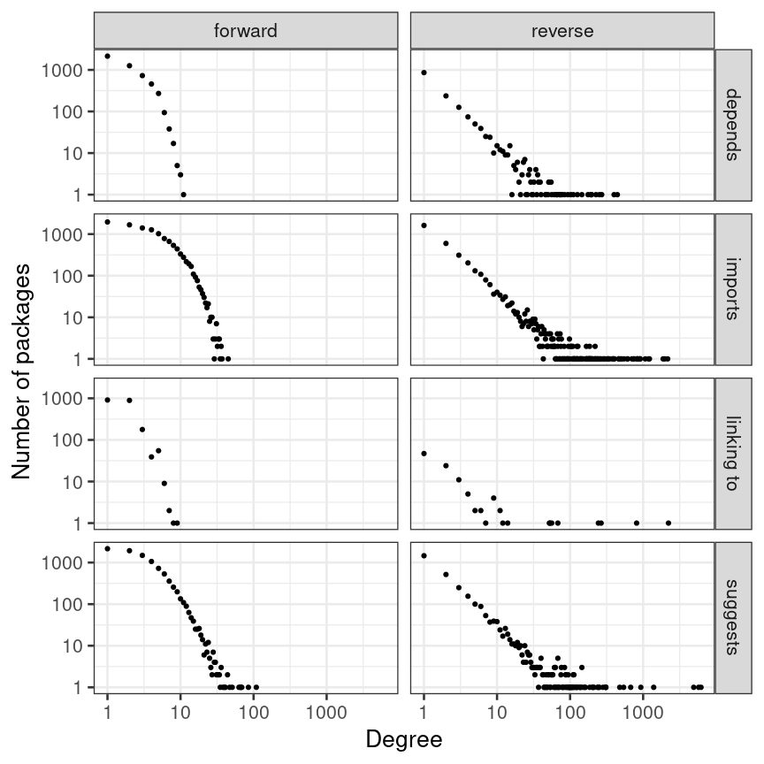

```r
gg0.summary <- df1.summary %>%
    dplyr::mutate(reverse = ifelse(reverse, "reverse", "forward")) %>%
    ggplot2::ggplot() +
    ggplot2::geom_point(ggplot2::aes(n, nn)) +
    ggplot2::facet_grid(type ~ reverse) +
    ggplot2::scale_x_log10() +
    ggplot2::scale_y_log10() +
    ggplot2::labs(x = "Degree", y = "Number of packages") +
    ggplot2::theme_bw(20)
gg0.summary
```

This shows the reverse dependencies, in particular `Reverse_depends` and `Reverse_imports`, follow the [power law](https://en.wikipedia.org/wiki/Power-law), which is empirically observed in various academic fields.

## Visualisation

We can now visualise (the giant component of) the CRAN network of `Depends`, using functions in the package **visNetwork**. To do this, we will need to convert the **igraph** object `g0.depends` to the node list and edge list as data frames.

```r
prefix <- "http://CRAN.R-project.org/package=" # canonical form
degrees <- igraph::degree(g0.depends)
set.seed(3579L)
clusters <- igraph::membership(igraph::cluster_spinglass(g0.depends))
df0.nodes <- dplyr::full_join(
    data.frame(id = names(degrees), value = degrees),
    data.frame(id = names(clusters), group = as.character(clusters)),
    "id") %>%
    dplyr::mutate(title = paste0('<a href=\"', prefix, id, '\">', id, '</a>'))
df0.edges <- igraph::as_data_frame(g0.depends, what = "edges")
```

By adding the column `title` in `df0.nodes`, we enable clicking the nodes and being directed to their CRAN pages, in the interactive visualisation below:

```r
set.seed(2345L)
vis0 <- visNetwork::visNetwork(df0.nodes, df0.edges, width = "100%", height = "720px") %>%
    visNetwork::visOptions(highlightNearest = TRUE) %>%
    visNetwork::visEdges(arrows = "to", color = list(opacity = 0.5)) %>%
    visNetwork::visNodes(fixed = TRUE) %>%
    visNetwork::visIgraphLayout(layout = "layout_with_drl")
vis0
```

[interactive chart not shown]

## Going forward

Methods in social network analysis, such as stochastic block models, can be applied to study the properties of the dependency network. Ideally, by analysing the dependencies of all CRAN packages, we can obtain a bird’s-eye view of the ecosystem. The number of reverse dependencies is modelled in this other vignette.